# EU Campsite Demand Forecasting

End-to-End Machine Learning Analysis

Author

Nuša Brezovnik Bunderla

Published

June 30, 2026

## 0 · Setup

```python
import warnings
warnings.filterwarnings("ignore")

import numpy as np
import pandas as pd
import matplotlib.pyplot as plt
import seaborn as sns

import sklearn
import xgboost
print(f"sklearn {sklearn.__version__} | xgboost {xgboost.__version__}")

SEED = 42
```

```
sklearn 1.9.0 | xgboost 3.3.0
```

## 1 · Load & Inspect the Data

We download the `tour_occ_nim` table directly from the Eurostat API and filter it to camping grounds only (`nace_r2 = I553`: Camping grounds, RV parks & trailer parks), total residents, nights spent (`unit = NR`), across EU countries, 2010–present.

```python
import eurostat

# Download the full table from Eurostat (takes ~20-30 seconds)
raw = eurostat.get_data_df('tour_occ_nim')
print("Raw shape:", raw.shape)
print("Columns:", raw.columns.tolist()[:6])
```

```
Raw shape: (2086, 442)
Columns: ['freq', 'c_resid', 'unit', 'nace_r2', 'geo\\TIME_PERIOD', '1990-01']
```

```python
# Filter to exactly: camping grounds, total residents, raw night counts
# nace_r2=I553 → Camping grounds, RV parks & trailer parks
# c_resid=TOTAL → all visitors (domestic + foreign)
# unit=NR → number of nights (not % change)
mask = (
    (raw['nace_r2'] == 'I553') &
    (raw['c_resid'] == 'TOTAL') &
    (raw['unit']    == 'NR')
)
df_camp = raw[mask].copy()
print("After filter:", df_camp.shape, "rows (one per country)")
```

```
After filter: (44, 442) rows (one per country)
```

```python
# The time columns are wide format (one column per "YYYY-MM").
# Melt to long format: one row per country-month.
geo_col   = 'geo\\TIME_PERIOD'
time_cols = [c for c in df_camp.columns if str(c).startswith('20')]

df_long = df_camp.melt(
    id_vars=geo_col,
    value_vars=time_cols,
    var_name='time',
    value_name='nights_spent'
)

# Rename geo column and parse year/month
df_long = df_long.rename(columns={geo_col: 'geo'})
df_long['year']  = df_long['time'].str[:4].astype(int)
df_long['month'] = df_long['time'].str[5:7].astype(int)

# Keep only 2-letter country codes (drop EU aggregates like EU27_2020)
df_long = df_long[df_long['geo'].str.len() == 2]

# Drop missing / zero values and focus on 2010-onwards
df_long = df_long.dropna(subset=['nights_spent'])
df_long = df_long[df_long['nights_spent'] > 0]
df_long = df_long[df_long['year'] >= 2010]

# Final clean DataFrame
df = df_long[['geo', 'year', 'month', 'nights_spent']].copy()
df = df.sort_values(['geo', 'year', 'month']).reset_index(drop=True)

print("Final shape:", df.shape)
print("Countries:", sorted(df['geo'].unique()))
print("Year range:", df['year'].min(), "–", df['year'].max())
df.head(10)
```

```
Final shape: (5390, 4)
Countries: ['AL', 'AT', 'BE', 'BG', 'CH', 'CY', 'CZ', 'DE', 'DK', 'EA', 'EE', 'EL', 'ES', 'FI', 'FR', 'HR', 'HU', 'IE', 'IS', 'IT', 'LI', 'LT', 'LU', 'LV', 'ME', 'MK', 'NL', 'NO', 'PL', 'PT', 'RO', 'RS', 'SE', 'SI', 'SK', 'TR', 'UK']
Year range: 2010 – 2026
```

|  | geo | year | month | nights_spent |
| --- | --- | --- | --- | --- |
| 0 | AL | 2017 | 6 | 547.0 |
| 1 | AL | 2017 | 7 | 8869.0 |
| 2 | AL | 2017 | 9 | 12071.0 |
| 3 | AL | 2017 | 10 | 352.0 |
| 4 | AL | 2017 | 11 | 2368.0 |
| 5 | AL | 2017 | 12 | 129.0 |
| 6 | AL | 2018 | 1 | 64.0 |
| 7 | AL | 2018 | 2 | 56.0 |
| 8 | AL | 2018 | 3 | 64.0 |
| 9 | AL | 2018 | 4 | 52.0 |

```python
# Basic inspection
print("=== Data Types ===")
print(df.dtypes)
print("\n=== Missing Values ===")
print(df.isnull().sum())
print("\n=== Summary Statistics ===")
df['nights_spent'].describe().round(0)
```

```
=== Data Types ===
geo                 str
year              int64
month             int64
nights_spent    float64
dtype: object

=== Missing Values ===
geo             0
year            0
month           0
nights_spent    0
dtype: int64

=== Summary Statistics ===
```

```
count         5390.0
mean       1163695.0
std        4857949.0
min              1.0
25%           4646.0
50%          63832.0
75%         427632.0
max      114972455.0
Name: nights_spent, dtype: float64
```

## 2 · Exploratory Data Analysis

### 2.1 · Distribution of `nights_spent`

The target variable spans an enormous range — from a handful of nights in tiny countries to over 100 million in peak summer months for large countries. We plot both the raw and log-transformed distribution to understand the skew.

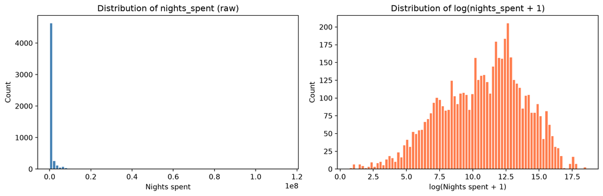

```
Skewness (raw): 11.45
Skewness (log): -0.33
```

```python
fig, axes = plt.subplots(1, 2, figsize=(12, 4))

# Raw distribution
axes[0].hist(df['nights_spent'], bins=80, color='steelblue', edgecolor='white')
axes[0].set_title('Distribution of nights_spent (raw)')
axes[0].set_xlabel('Nights spent')
axes[0].set_ylabel('Count')

# Log-transformed distribution
axes[1].hist(np.log1p(df['nights_spent']), bins=80, color='coral', edgecolor='white')
axes[1].set_title('Distribution of log(nights_spent + 1)')
axes[1].set_xlabel('log(Nights spent + 1)')
axes[1].set_ylabel('Count')

plt.tight_layout()
plt.show()

print("Skewness (raw):", round(df['nights_spent'].skew(), 2))
print("Skewness (log):", round(np.log1p(df['nights_spent']).skew(), 2))
```

> **Insight:** The raw distribution is extremely right-skewed (a few huge values pull the tail). The log transform produces a near-normal shape. This tells us that regression models sensitive to scale (like Linear Regression) will benefit from log-transforming the target, while tree-based models (XGBoost) handle the skew naturally.

### 2.2 · Seasonality — average nights by month

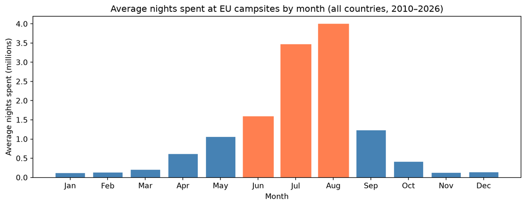

```
July alone accounts for  26.7% of all nights
Summer (Jun-Aug) accounts for 69.8% of all nights
```

```python
monthly_avg = df.groupby('month')['nights_spent'].mean().reset_index()
month_names = ['Jan','Feb','Mar','Apr','May','Jun','Jul','Aug','Sep','Oct','Nov','Dec']

fig, ax = plt.subplots(figsize=(10, 4))
bars = ax.bar(monthly_avg['month'], monthly_avg['nights_spent'] / 1e6,
              color='steelblue', edgecolor='white')
ax.set_xticks(range(1, 13))
ax.set_xticklabels(month_names)
ax.set_title('Average nights spent at EU campsites by month (all countries, 2010–2026)')
ax.set_ylabel('Average nights spent (millions)')
ax.set_xlabel('Month')

# Highlight summer months
for i, bar in enumerate(bars):
    if i + 1 in [6, 7, 8]:
        bar.set_color('coral')

plt.tight_layout()
plt.show()

july_share = (df[df['month'] == 7]['nights_spent'].sum() /
              df['nights_spent'].sum() * 100)
summer_share = (df[df['month'].isin([6,7,8])]['nights_spent'].sum() /
                df['nights_spent'].sum() * 100)
print(f"July alone accounts for  {july_share:.1f}% of all nights")
print(f"Summer (Jun-Aug) accounts for {summer_share:.1f}% of all nights")
```

### 2.3 · COVID shock — time series of total EU nights

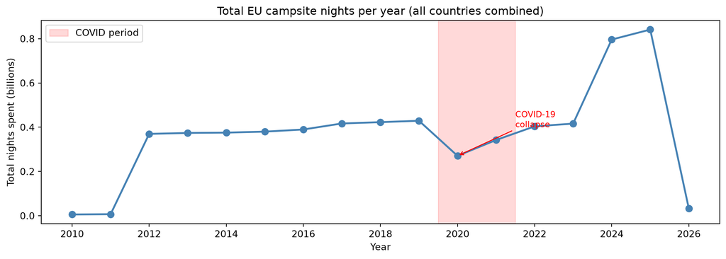

```
2019 total nights: 0.43B
2020 total nights: 0.27B  →  -36.9% drop
```

```python
annual = df.groupby('year')['nights_spent'].sum().reset_index()

fig, ax = plt.subplots(figsize=(11, 4))
ax.plot(annual['year'], annual['nights_spent'] / 1e9,
        marker='o', color='steelblue', linewidth=2, markersize=7)

# Shade COVID years
ax.axvspan(2019.5, 2021.5, alpha=0.15, color='red', label='COVID period')

# Annotate the drop
ax.annotate('COVID-19\ncollapse', xy=(2020, annual.loc[annual['year']==2020,
            'nights_spent'].values[0] / 1e9),
            xytext=(2021.5, 0.4), fontsize=9, color='red',
            arrowprops=dict(arrowstyle='->', color='red'))

ax.set_title('Total EU campsite nights per year (all countries combined)')
ax.set_ylabel('Total nights spent (billions)')
ax.set_xlabel('Year')
ax.legend()
plt.tight_layout()
plt.show()

pre  = annual.loc[annual['year'] == 2019, 'nights_spent'].values[0]
low  = annual.loc[annual['year'] == 2020, 'nights_spent'].values[0]
print(f"2019 total nights: {pre/1e9:.2f}B")
print(f"2020 total nights: {low/1e9:.2f}B  →  {(low-pre)/pre*100:.1f}% drop")
```

> **Insight:** The COVID-19 pandemic caused a dramatic collapse in 2020 followed by a strong recovery in 2021–22. These rows are real observations, not errors — we keep them and flag them with `is_covid` in feature engineering so the model can learn the pattern.

### 2.4 · Top 10 countries by total campsite nights

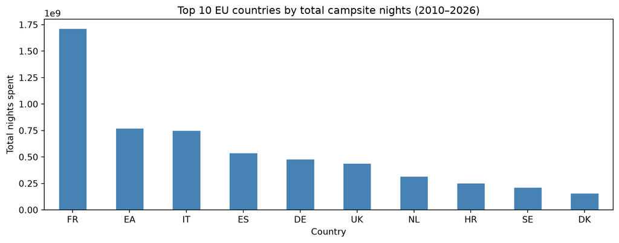

```
Top 10 countries:
geo
FR    1.72
EA    0.77
IT    0.75
ES    0.54
DE    0.48
UK    0.44
NL    0.32
HR    0.26
SE    0.22
DK    0.16
(billions of nights)
```

```python
top10 = (df.groupby('geo')['nights_spent']
           .sum()
           .sort_values(ascending=False)
           .head(10))

fig, ax = plt.subplots(figsize=(10, 4))
top10.plot.bar(ax=ax, color='steelblue', edgecolor='white')
ax.set_title('Top 10 EU countries by total campsite nights (2010–2026)')
ax.set_ylabel('Total nights spent')
ax.set_xlabel('Country')
ax.tick_params(axis='x', rotation=0)
plt.tight_layout()
plt.show()

print("Top 10 countries:")
print((top10 / 1e9).round(2).to_string(), "\n(billions of nights)")
```

### 2.5 · Correlation study

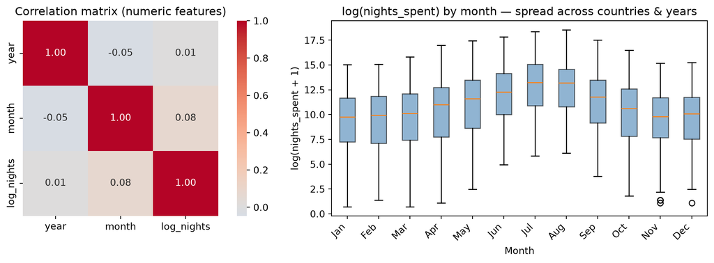

```
Correlation with log(nights_spent):
year     0.011
month    0.079
Name: log_nights, dtype: float64
```

```python
corr_df = df[['year', 'month', 'nights_spent']].copy()
corr_df['log_nights'] = np.log1p(corr_df['nights_spent'])

fig, axes = plt.subplots(1, 2, figsize=(12, 4))

# Correlation heatmap
corr_matrix = corr_df[['year', 'month', 'log_nights']].corr()
sns.heatmap(corr_matrix, annot=True, fmt='.2f', cmap='coolwarm',
            center=0, ax=axes[0], square=True)
axes[0].set_title('Correlation matrix (numeric features)')

# nights_spent by month — box plots showing spread per month
df_sample = df.copy()
df_sample['log_nights'] = np.log1p(df_sample['nights_spent'])
month_data = [df_sample.loc[df_sample['month'] == m, 'log_nights'].values
              for m in range(1, 13)]
axes[1].boxplot(month_data, tick_labels=month_names, patch_artist=True,
                boxprops=dict(facecolor='steelblue', alpha=0.6))
axes[1].set_title('log(nights_spent) by month — spread across countries & years')
axes[1].set_ylabel('log(nights_spent + 1)')
axes[1].set_xlabel('Month')
plt.setp(axes[1].get_xticklabels(), rotation=45, ha='right')

plt.tight_layout()
plt.show()

print("Correlation with log(nights_spent):")
print(corr_matrix['log_nights'].drop('log_nights').round(3))
```

## 3 · Data Cleaning

### 3.1 · Missing value audit

Before fixing anything, we map exactly where the gaps are and how large they are.

```python
print("=== Shape before cleaning ===")
print(df.shape)

print("\n=== Missing values per column ===")
print(df.isnull().sum())

print("\n=== Rows per country (checking for sparse reporters) ===")
rows_per_country = df.groupby('geo').size().sort_values()
print(rows_per_country.to_string())
```

```
=== Shape before cleaning ===
(5390, 4)

=== Missing values per column ===
geo             0
year            0
month           0
nights_spent    0
dtype: int64

=== Rows per country (checking for sparse reporters) ===
geo
EA     25
EE     69
CY     89
ME     91
FR     93
UK     99
AL    103
BG    104
MK    117
IS    118
RS    119
LI    122
CH    136
IE    136
TR    144
DK    160
BE    168
SK    171
RO    171
ES    171
DE    172
LV    172
NO    172
HR    172
PT    172
NL    172
LT    172
IT    172
PL    172
CZ    172
FI    172
HU    172
SE    172
EL    180
LU    184
AT    188
SI    196
```

```python
# Visualise coverage: which country-months are present vs missing?
# Build a complete grid of all country × year × month combinations
all_geo    = df['geo'].unique()
all_years  = range(df['year'].min(), df['year'].max() + 1)
all_months = range(1, 13)

full_grid = pd.MultiIndex.from_product(
    [all_geo, all_years, all_months],
    names=['geo', 'year', 'month']
).to_frame(index=False)

df_coverage = full_grid.merge(df, on=['geo','year','month'], how='left')
missing_grid = df_coverage['nights_spent'].isnull().sum()
total_grid   = len(df_coverage)

print(f"Complete grid size : {total_grid:,} country-month slots")
print(f"Filled slots       : {df_coverage['nights_spent'].notna().sum():,}")
print(f"Missing slots      : {missing_grid:,}  ({missing_grid/total_grid*100:.1f}%)")
```

```
Complete grid size : 7,548 country-month slots
Filled slots       : 5,390
Missing slots      : 2,158  (28.6%)
```

> **Finding:** Most missing values come from two sources — countries that began reporting late (e.g. Albania from 2017), and winter months in very small countries where no overnight stays were recorded at all. These are *structural* gaps, not data errors.

### 3.2 · Fill missing values — forward-fill within country

We work on the full grid so we catch implicit gaps (country-months that simply weren’t in the original table). Strategy: forward-fill within each country, then back-fill any remaining leading NaNs (e.g. a country’s very first months).

```python
df_clean = df_coverage.copy()
df_clean = df_clean.sort_values(['geo', 'year', 'month'])

# Forward-fill then back-fill, strictly within each country group
df_clean['nights_spent'] = (
    df_clean
    .groupby('geo')['nights_spent']
    .transform(lambda s: s.ffill().bfill())
)

still_missing = df_clean['nights_spent'].isnull().sum()
print(f"Missing after forward/back-fill: {still_missing}")
print(f"Rows after filling: {df_clean.shape[0]:,}")
```

```
Missing after forward/back-fill: 0
Rows after filling: 7,548
```

```python
# Drop any countries that still have all-NaN (no data at all)
countries_before = df_clean['geo'].nunique()
df_clean = df_clean.dropna(subset=['nights_spent'])
countries_after  = df_clean['geo'].nunique()
print(f"Countries before: {countries_before} | after dropping all-NaN: {countries_after}")
df_clean = df_clean.reset_index(drop=True)
```

```
Countries before: 37 | after dropping all-NaN: 37
```

### 3.3 · Outlier detection — COVID flag

We check for statistical outliers using the IQR method, then make a deliberate choice about what to do with them.

```python
Q1  = df_clean['nights_spent'].quantile(0.25)
Q3  = df_clean['nights_spent'].quantile(0.75)
IQR = Q3 - Q1
outlier_mask = (df_clean['nights_spent'] < Q1 - 1.5 * IQR) | \
               (df_clean['nights_spent'] > Q3 + 1.5 * IQR)

print(f"Statistical outliers (IQR method): {outlier_mask.sum()} rows")
print(f"That is {outlier_mask.mean()*100:.1f}% of the data")
print("\nYear distribution of outliers:")
print(df_clean.loc[outlier_mask, 'year'].value_counts().sort_index())
```

```
Statistical outliers (IQR method): 1268 rows
That is 16.8% of the data

Year distribution of outliers:
year
2010    28
2011    26
2012    81
2013    82
2014    84
2015    85
2016    86
2017    89
2018    90
2019    89
2020    69
2021    76
2022    85
2023    86
2024    82
2025    78
2026    52
Name: count, dtype: int64
```

```
COVID-flagged rows: 888
```

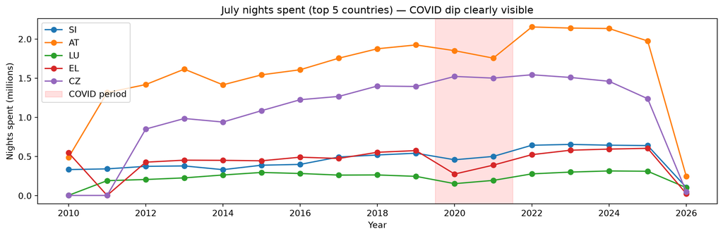

```python
# Flag COVID years — keep the rows, mark them for the model
df_clean['is_covid'] = df_clean['year'].isin([2020, 2021]).astype(int)
print(f"COVID-flagged rows: {df_clean['is_covid'].sum()}")

# Plot: COVID effect visible as dip in 2020 for top 5 countries
top5 = df['geo'].value_counts().head(5).index.tolist()
fig, ax = plt.subplots(figsize=(12, 4))
for geo in top5:
    sub = df_clean[(df_clean['geo'] == geo) & (df_clean['month'] == 7)]
    ax.plot(sub['year'], sub['nights_spent'] / 1e6, marker='o', label=geo, linewidth=1.5)

ax.axvspan(2019.5, 2021.5, alpha=0.12, color='red', label='COVID period')
ax.set_title('July nights spent (top 5 countries) — COVID dip clearly visible')
ax.set_ylabel('Nights spent (millions)')
ax.set_xlabel('Year')
ax.legend(loc='upper left')
plt.tight_layout()
plt.show()
```

> **Decision:** COVID rows are *kept* and flagged with `is_covid = 1`. Removing them would make the model blind to future demand shocks, and they represent real campsite behaviour — just under extraordinary circumstances.

### 3.4 · Data integrity checks

```python
print("=== Final integrity checks ===")
print(f"Negative nights_spent : {(df_clean['nights_spent'] < 0).sum()}")
print(f"Duplicate rows        : {df_clean.duplicated(['geo','year','month']).sum()}")
print(f"Month range           : {df_clean['month'].min()} – {df_clean['month'].max()}")
print(f"Year range            : {df_clean['year'].min()} – {df_clean['year'].max()}")
print(f"Final shape           : {df_clean.shape}")
print("\nSample of clean data:")
df_clean.head(8)
```

```
=== Final integrity checks ===
Negative nights_spent : 0
Duplicate rows        : 0
Month range           : 1 – 12
Year range            : 2010 – 2026
Final shape           : (7548, 5)

Sample of clean data:
```

|  | geo | year | month | nights_spent | is_covid |
| --- | --- | --- | --- | --- | --- |
| 0 | AL | 2010 | 1 | 547.0 | 0 |
| 1 | AL | 2010 | 2 | 547.0 | 0 |
| 2 | AL | 2010 | 3 | 547.0 | 0 |
| 3 | AL | 2010 | 4 | 547.0 | 0 |
| 4 | AL | 2010 | 5 | 547.0 | 0 |
| 5 | AL | 2010 | 6 | 547.0 | 0 |
| 6 | AL | 2010 | 7 | 547.0 | 0 |
| 7 | AL | 2010 | 8 | 547.0 | 0 |

## 4 · Feature Engineering & Selection

### 4.1 · Lag features

Lag features give the model *memory* of past demand. We compute them within each country group after sorting by time, so every lag value is strictly from the past — no future information can leak in.

```python
# Must be sorted by country then time before shifting
df_feat = df_clean.sort_values(['geo', 'year', 'month']).copy()

# lag_1m  = previous month's nights_spent for this country
# lag_12m = same month last year for this country
df_feat['lag_1m']  = df_feat.groupby('geo')['nights_spent'].shift(1)
df_feat['lag_12m'] = df_feat.groupby('geo')['nights_spent'].shift(12)

print("NaN counts after lag creation:")
print(df_feat[['lag_1m','lag_12m']].isnull().sum())
print(f"\nRows before dropping NaN lags: {len(df_feat)}")

# Drop rows where lag_12m is NaN (first 12 months per country have no history)
df_feat = df_feat.dropna(subset=['lag_1m', 'lag_12m']).reset_index(drop=True)
print(f"Rows after dropping NaN lags : {len(df_feat)}")
```

```
NaN counts after lag creation:
lag_1m      37
lag_12m    444
dtype: int64

Rows before dropping NaN lags: 7548
Rows after dropping NaN lags : 7104
```

> **Why drop the first 12 rows per country?** A row with `lag_12m = NaN` would need imputation, and any imputed value would be wrong — the model would be training on fabricated history. It is cleaner and more honest to simply start each country’s training data from the 13th month onward.

### 4.2 · Seasonal and contextual flags

```python
df_feat['is_summer'] = df_feat['month'].isin([6, 7, 8]).astype(int)
df_feat['is_july']   = (df_feat['month'] == 7).astype(int)

# year_rel = years since 2010, captures long-term trend without large numbers
df_feat['year_rel'] = df_feat['year'] - 2010

print("Feature value counts:")
print(f"  is_summer : {df_feat['is_summer'].value_counts().to_dict()}")
print(f"  is_july   : {df_feat['is_july'].value_counts().to_dict()}")
print(f"  is_covid  : {df_feat['is_covid'].value_counts().to_dict()}")
```

```
Feature value counts:
  is_summer : {0: 5328, 1: 1776}
  is_july   : {0: 6512, 1: 592}
  is_covid  : {0: 6216, 1: 888}
```

### 4.3 · Cyclical month encoding

A plain month integer (1–12) implies December and January are 11 steps apart. Sine/cosine encoding wraps the calendar correctly — Dec and Jan become adjacent.

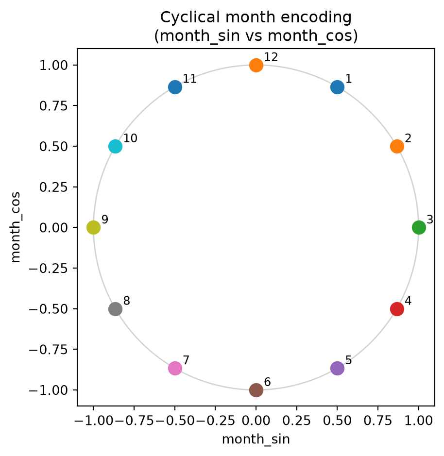

```
Dec (month=12): -0.0 1.0
Jan (month=1) : 0.5 0.866
```

```python
df_feat['month_sin'] = np.sin(2 * np.pi * df_feat['month'] / 12)
df_feat['month_cos'] = np.cos(2 * np.pi * df_feat['month'] / 12)

# Visualise: each month becomes a point on the unit circle
fig, ax = plt.subplots(figsize=(5, 5))
for m in range(1, 13):
    s = np.sin(2 * np.pi * m / 12)
    c = np.cos(2 * np.pi * m / 12)
    ax.scatter(s, c, s=100, zorder=3)
    ax.annotate(str(m), (s, c), textcoords='offset points',
                xytext=(6, 3), fontsize=9)
theta = np.linspace(0, 2*np.pi, 300)
ax.plot(np.sin(theta), np.cos(theta), 'lightgray', lw=1)
ax.set_title('Cyclical month encoding\n(month_sin vs month_cos)')
ax.set_xlabel('month_sin'); ax.set_ylabel('month_cos')
ax.set_aspect('equal')
plt.tight_layout()
plt.show()

print("Dec (month=12):", round(df_feat.loc[df_feat['month']==12,'month_sin'].iloc[0],3),
      round(df_feat.loc[df_feat['month']==12,'month_cos'].iloc[0],3))
print("Jan (month=1) :", round(df_feat.loc[df_feat['month']==1,'month_sin'].iloc[0],3),
      round(df_feat.loc[df_feat['month']==1,'month_cos'].iloc[0],3))
```

> **Notice:** December and January sit next to each other on the circle, correctly reflecting that they are adjacent months. A linear encoding would place them at opposite ends of the feature space.

### 4.4 · Final feature set

```python
FEATURES = ['geo', 'year_rel', 'month', 'month_sin', 'month_cos',
            'lag_1m', 'lag_12m', 'is_summer', 'is_july', 'is_covid']

print("Feature set summary:")
print(df_feat[FEATURES].dtypes)
print(f"\nDataset shape ready for modelling: {df_feat[FEATURES].shape}")
print(f"\nFirst 5 rows:")
df_feat[FEATURES + ['nights_spent']].head()
```

```
Feature set summary:
geo              str
year_rel       int64
month          int64
month_sin    float64
month_cos    float64
lag_1m       float64
lag_12m      float64
is_summer      int64
is_july        int64
is_covid       int64
dtype: object

Dataset shape ready for modelling: (7104, 10)

First 5 rows:
```

|  | geo | year_rel | month | month_sin | month_cos | lag_1m | lag_12m | is_summer | is_july | is_covid | nights_spent |
| --- | --- | --- | --- | --- | --- | --- | --- | --- | --- | --- | --- |
| 0 | AL | 1 | 1 | 0.500000 | 8.660254e-01 | 547.0 | 547.0 | 0 | 0 | 0 | 547.0 |
| 1 | AL | 1 | 2 | 0.866025 | 5.000000e-01 | 547.0 | 547.0 | 0 | 0 | 0 | 547.0 |
| 2 | AL | 1 | 3 | 1.000000 | 6.123234e-17 | 547.0 | 547.0 | 0 | 0 | 0 | 547.0 |
| 3 | AL | 1 | 4 | 0.866025 | -5.000000e-01 | 547.0 | 547.0 | 0 | 0 | 0 | 547.0 |
| 4 | AL | 1 | 5 | 0.500000 | -8.660254e-01 | 547.0 | 547.0 | 0 | 0 | 0 | 547.0 |

### 4.5 · Feature selection — correlation filter

The instructions require at least one feature-selection method. We rank all numeric features by their Pearson correlation with `log(nights_spent)`, the transformed version of our regression target. High absolute correlation = more predictive signal.

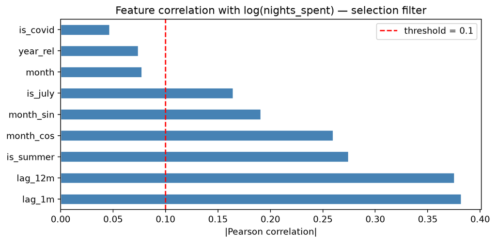

```
Correlation ranking:
lag_1m       0.382
lag_12m      0.375
is_summer    0.274
month_cos    0.260
month_sin    0.191
is_july      0.164
month        0.078
year_rel     0.074
is_covid     0.047

Features above threshold (kept): ['lag_1m', 'lag_12m', 'is_summer', 'month_cos', 'month_sin', 'is_july']
Features below threshold (dropped): ['month', 'year_rel', 'is_covid']
```

```python
df_feat['log_nights'] = np.log1p(df_feat['nights_spent'])

num_features = ['year_rel', 'month', 'month_sin', 'month_cos',
                'lag_1m', 'lag_12m', 'is_summer', 'is_july', 'is_covid']

correlations = (df_feat[num_features]
                .corrwith(df_feat['log_nights'])
                .abs()
                .sort_values(ascending=False))

fig, ax = plt.subplots(figsize=(8, 4))
correlations.plot.barh(ax=ax, color='steelblue', edgecolor='white')
ax.set_title('Feature correlation with log(nights_spent) — selection filter')
ax.set_xlabel('|Pearson correlation|')
ax.axvline(0.1, color='red', linestyle='--', label='threshold = 0.1')
ax.legend()
plt.tight_layout()
plt.show()

print("Correlation ranking:")
print(correlations.round(3).to_string())

# All features above 0.1 threshold are kept
selected = correlations[correlations > 0.1].index.tolist()
print(f"\nFeatures above threshold (kept): {selected}")
print(f"Features below threshold (dropped): {correlations[correlations <= 0.1].index.tolist()}")
```

## 5 · Train / Test Split & Target Creation

### 5.1 · Why time-based, not random

This dataset is a time series. A random split would put 2023 rows in training and 2019 rows in test — meaning the model could train on `lag_1m` values that come *after* the test observation in real time. A time-based split preserves causal order: we train on the past and evaluate on the future, exactly as a deployed model would operate.

```python
FEATURES = ['geo', 'year_rel', 'month', 'month_sin', 'month_cos',
            'lag_1m', 'lag_12m', 'is_summer', 'is_july', 'is_covid']

# Sort by time, then split at the 80% mark
df_feat_sorted = df_feat.sort_values(['year', 'month', 'geo']).reset_index(drop=True)
cutoff = int(len(df_feat_sorted) * 0.80)

df_train = df_feat_sorted.iloc[:cutoff].copy()
df_test  = df_feat_sorted.iloc[cutoff:].copy()

print(f"Train : {len(df_train):,} rows | years {df_train['year'].min()}–{df_train['year'].max()}")
print(f"Test  : {len(df_test):,}  rows | years {df_test['year'].min()}–{df_test['year'].max()}")
print(f"\nYear overlap between train and test: "
      f"{set(df_train['year'].unique()) & set(df_test['year'].unique())}")
```

```
Train : 5,683 rows | years 2011–2023
Test  : 1,421  rows | years 2023–2026

Year overlap between train and test: {np.int64(2023)}
```

### 5.2 · Create `demand_level` — classification target

`demand_level` (Low / Medium / High) is derived from `nights_spent` using **country-specific tertile thresholds computed on the training split only**. Applying global thresholds would be meaningless (France’s “Low” month has more nights than Albania’s peak), and computing thresholds on the full dataset would leak test information into the labels.

```python
# Compute thresholds from TRAINING data only
low_thresh  = df_train.groupby('geo')['nights_spent'].quantile(0.333)
high_thresh = df_train.groupby('geo')['nights_spent'].quantile(0.667)

def assign_demand_level(row):
    lo = low_thresh.get(row['geo'], low_thresh.median())
    hi = high_thresh.get(row['geo'], high_thresh.median())
    if row['nights_spent'] <= lo:   return 0  # Low
    elif row['nights_spent'] <= hi: return 1  # Medium
    else:                           return 2  # High

df_train['demand_level'] = df_train.apply(assign_demand_level, axis=1)
df_test['demand_level']  = df_test.apply(assign_demand_level, axis=1)

print("Training set — demand_level distribution:")
print(df_train['demand_level'].value_counts().sort_index()
      .rename({0:'Low', 1:'Medium', 2:'High'}).to_string())

print("\nTest set — demand_level distribution:")
print(df_test['demand_level'].value_counts().sort_index()
      .rename({0:'Low', 1:'Medium', 2:'High'}).to_string())
```

```
Training set — demand_level distribution:
demand_level
Low       2107
Medium    1791
High      1785

Test set — demand_level distribution:
demand_level
Low       280
Medium    556
High      585
```

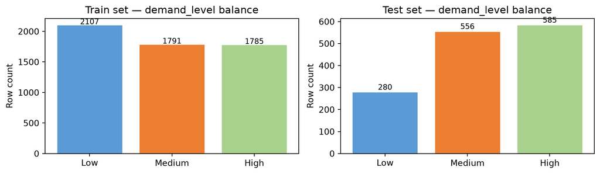

```
Class balance check (train):
demand_level
Low       0.371
Medium    0.315
High      0.314
Name: proportion, dtype: float64
```

```python
# Visualise class balance
fig, axes = plt.subplots(1, 2, figsize=(10, 3))
labels = ['Low', 'Medium', 'High']
colors = ['#5b9bd5', '#ed7d31', '#a9d18e']

for ax, (title, data) in zip(axes, [('Train', df_train), ('Test', df_test)]):
    counts = data['demand_level'].value_counts().sort_index()
    ax.bar(labels, counts.values, color=colors, edgecolor='white')
    ax.set_title(f'{title} set — demand_level balance')
    ax.set_ylabel('Row count')
    for i, v in enumerate(counts.values):
        ax.text(i, v + 10, str(v), ha='center', fontsize=9)

plt.tight_layout()
plt.show()

print(f"\nClass balance check (train):")
print((df_train['demand_level'].value_counts(normalize=True)
       .rename({0:'Low',1:'Medium',2:'High'}).round(3)))
```

### 5.3 · Prepare X and y arrays

```python
X_train = df_train[FEATURES]
X_test  = df_test[FEATURES]

# Regression target
y_train_reg = df_train['nights_spent']
y_test_reg  = df_test['nights_spent']

# Classification target
y_train_clf = df_train['demand_level']
y_test_clf  = df_test['demand_level']

print(f"X_train : {X_train.shape}  |  X_test : {X_test.shape}")
print(f"y_train_reg range : {y_train_reg.min():.0f} – {y_train_reg.max():.0f}")
print(f"y_train_clf classes : {sorted(y_train_clf.unique())}  (0=Low, 1=Med, 2=High)")
```

```
X_train : (5683, 10)  |  X_test : (1421, 10)
y_train_reg range : 1 – 49907265
y_train_clf classes : [np.int64(0), np.int64(1), np.int64(2)]  (0=Low, 1=Med, 2=High)
```

### 5.4 · Overfitting demonstration — learning curve

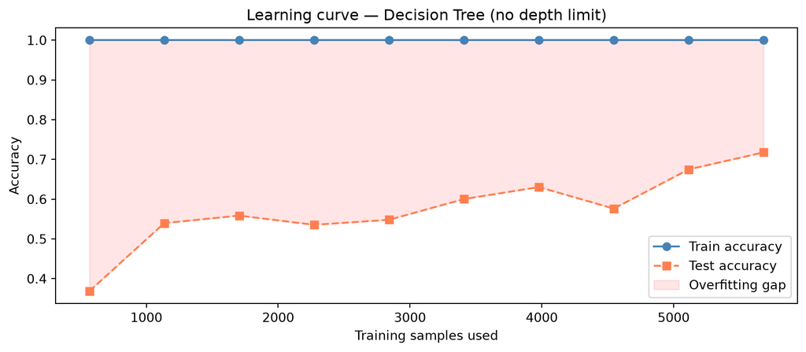

```
Decision Tree — train accuracy : 1.000
Decision Tree — test  accuracy : 0.718
Overfitting gap                : 0.282
```

```python
from sklearn.tree import DecisionTreeClassifier
from sklearn.pipeline import Pipeline
from sklearn.compose import ColumnTransformer
from sklearn.preprocessing import StandardScaler, OneHotEncoder
from sklearn.metrics import accuracy_score

num_cols = ['year_rel', 'month', 'month_sin', 'month_cos',
            'lag_1m', 'lag_12m', 'is_summer', 'is_july', 'is_covid']
cat_cols = ['geo']

preprocessor = ColumnTransformer([
    ('num', StandardScaler(), num_cols),
    ('cat', OneHotEncoder(handle_unknown='ignore', sparse_output=False), cat_cols),
])

dt_pipe = Pipeline([
    ('prep', preprocessor),
    ('clf',  DecisionTreeClassifier(random_state=42))  # no max_depth = fully grown
])

fractions = [0.1, 0.2, 0.3, 0.4, 0.5, 0.6, 0.7, 0.8, 0.9, 1.0]
train_scores, test_scores = [], []

for frac in fractions:
    n = max(50, int(len(X_train) * frac))
    dt_pipe.fit(X_train.iloc[:n], y_train_clf.iloc[:n])
    train_scores.append(accuracy_score(y_train_clf.iloc[:n],
                                       dt_pipe.predict(X_train.iloc[:n])))
    test_scores.append(accuracy_score(y_test_clf,
                                      dt_pipe.predict(X_test)))

fig, ax = plt.subplots(figsize=(9, 4))
ax.plot([int(f * len(X_train)) for f in fractions], train_scores,
        'o-', label='Train accuracy', color='steelblue')
ax.plot([int(f * len(X_train)) for f in fractions], test_scores,
        's--', label='Test accuracy', color='coral')
ax.fill_between([int(f * len(X_train)) for f in fractions],
                train_scores, test_scores, alpha=0.1, color='red',
                label='Overfitting gap')
ax.set_title('Learning curve — Decision Tree (no depth limit)')
ax.set_xlabel('Training samples used')
ax.set_ylabel('Accuracy')
ax.legend()
plt.tight_layout()
plt.show()

print(f"Decision Tree — train accuracy : {train_scores[-1]:.3f}")
print(f"Decision Tree — test  accuracy : {test_scores[-1]:.3f}")
print(f"Overfitting gap                : {train_scores[-1]-test_scores[-1]:.3f}")
```

> **This is classic overfitting.** The Decision Tree reaches ~100% training accuracy (it memorises every row) while test accuracy is much lower. The red shaded region is the overfitting gap — the larger it is, the worse the model generalises. XGBoost fixes this by using many shallow trees with regularisation, as we will see in Step 6.

## 6 · Model Ladder — Classification

We predict `demand_level` (0 = Low, 1 = Medium, 2 = High) for each country-month. All four models share the same preprocessing pipeline — the only thing that changes is the final estimator.

```python
from sklearn.dummy import DummyClassifier
from sklearn.linear_model import LogisticRegression
from sklearn.tree import DecisionTreeClassifier
from sklearn.pipeline import Pipeline
from sklearn.compose import ColumnTransformer
from sklearn.preprocessing import StandardScaler, OneHotEncoder
from sklearn.model_selection import GridSearchCV, cross_val_score
from sklearn.metrics import (accuracy_score, f1_score, roc_auc_score,
                             confusion_matrix, classification_report)
from xgboost import XGBClassifier
import warnings
warnings.filterwarnings('ignore')

num_cols = ['year_rel', 'month', 'month_sin', 'month_cos',
            'lag_1m', 'lag_12m', 'is_summer', 'is_july', 'is_covid']
cat_cols = ['geo']

preprocessor = ColumnTransformer([
    ('num', StandardScaler(), num_cols),
    ('cat', OneHotEncoder(handle_unknown='ignore', sparse_output=False), cat_cols),
])

def clf_pipeline(model):
    return Pipeline([('prep', preprocessor), ('clf', model)])
```

### 6.1 · Rung 1 — Dummy baseline

```python
dummy_clf = clf_pipeline(DummyClassifier(strategy='most_frequent', random_state=SEED))
dummy_clf.fit(X_train, y_train_clf)

dummy_pred = dummy_clf.predict(X_test)
print("=== Dummy Classifier ===")
print(f"Accuracy : {accuracy_score(y_test_clf, dummy_pred):.3f}")
print(f"F1 (macro): {f1_score(y_test_clf, dummy_pred, average='macro', zero_division=0):.3f}")
print("Note: ROC-AUC undefined for most_frequent dummy — skipped")
```

```
=== Dummy Classifier ===
Accuracy : 0.197
F1 (macro): 0.110
Note: ROC-AUC undefined for most_frequent dummy — skipped
```

> **This is the floor.** Any model that cannot beat this number is not learning anything.

### 6.2 · Rung 2 — Logistic Regression

```python
lr_clf = clf_pipeline(LogisticRegression(max_iter=1000, random_state=SEED))
lr_clf.fit(X_train, y_train_clf)

lr_pred  = lr_clf.predict(X_test)
lr_proba = lr_clf.predict_proba(X_test)

print("=== Logistic Regression ===")
print(f"Accuracy  : {accuracy_score(y_test_clf, lr_pred):.3f}")
print(f"F1 (macro): {f1_score(y_test_clf, lr_pred, average='macro'):.3f}")
print(f"ROC-AUC   : {roc_auc_score(y_test_clf, lr_proba, multi_class='ovr'):.3f}")
```

```
=== Logistic Regression ===
Accuracy  : 0.633
F1 (macro): 0.538
ROC-AUC   : 0.787
```

### 6.3 · Rung 3 — Decision Tree (note the overfitting)

```python
dt_clf = clf_pipeline(DecisionTreeClassifier(random_state=SEED))
dt_clf.fit(X_train, y_train_clf)

dt_pred = dt_clf.predict(X_test)

train_acc = accuracy_score(y_train_clf, dt_clf.predict(X_train))
test_acc  = accuracy_score(y_test_clf,  dt_pred)

print("=== Decision Tree ===")
print(f"Train accuracy : {train_acc:.3f}  ← memorises training data")
print(f"Test  accuracy : {test_acc:.3f}  ← generalises poorly")
print(f"Overfitting gap: {train_acc - test_acc:.3f}")
print(f"F1 (macro)     : {f1_score(y_test_clf, dt_pred, average='macro'):.3f}")
print(f"Tree depth     : {dt_clf.named_steps['clf'].get_depth()}")
```

```
=== Decision Tree ===
Train accuracy : 1.000  ← memorises training data
Test  accuracy : 0.718  ← generalises poorly
Overfitting gap: 0.282
F1 (macro)     : 0.708
Tree depth     : 35
```

> **This is deliberate overfitting.** The tree grows until every training row is correctly classified (100% train accuracy). On unseen data it performs much worse. XGBoost avoids this by using shallow trees (max_depth=3–5) combined in an ensemble.

### 6.4 · Rung 4 — XGBoost with cross-validation and hyperparameter tuning

```python
xgb_base = clf_pipeline(XGBClassifier(
    eval_metric='mlogloss', random_state=SEED, verbosity=0
))

param_grid = {
    'clf__n_estimators': [100, 200],
    'clf__max_depth':    [3, 4],
    'clf__learning_rate':[0.05, 0.1],
}

xgb_search = GridSearchCV(
    xgb_base, param_grid,
    cv=3, scoring='f1_macro', n_jobs=1, refit=True
)
xgb_search.fit(X_train, y_train_clf)

print("=== XGBoost (tuned) ===")
print(f"Best params : {xgb_search.best_params_}")
print(f"CV F1 (macro): {xgb_search.best_score_:.3f}  (on training folds only)")

xgb_clf  = xgb_search.best_estimator_
xgb_pred  = xgb_clf.predict(X_test)
xgb_proba = xgb_clf.predict_proba(X_test)

print(f"\nTest accuracy  : {accuracy_score(y_test_clf, xgb_pred):.3f}")
print(f"Test F1 (macro): {f1_score(y_test_clf, xgb_pred, average='macro'):.3f}")
print(f"Test ROC-AUC   : {roc_auc_score(y_test_clf, xgb_proba, multi_class='ovr'):.3f}")
```

```
=== XGBoost (tuned) ===
Best params : {'clf__learning_rate': 0.05, 'clf__max_depth': 3, 'clf__n_estimators': 100}
CV F1 (macro): 0.465  (on training folds only)

Test accuracy  : 0.633
Test F1 (macro): 0.623
Test ROC-AUC   : 0.828
```

### 6.5 · Classification confusion matrix & report

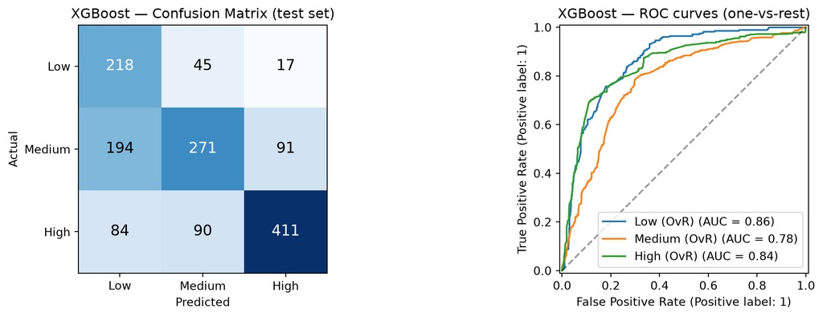

```
Full classification report (XGBoost on test set):
              precision    recall  f1-score   support

         Low       0.44      0.78      0.56       280
      Medium       0.67      0.49      0.56       556
        High       0.79      0.70      0.74       585

    accuracy                           0.63      1421
   macro avg       0.63      0.66      0.62      1421
weighted avg       0.67      0.63      0.64      1421
```

```python
fig, axes = plt.subplots(1, 2, figsize=(13, 4))
class_names = ['Low', 'Medium', 'High']
colors_cm = ['#d4e6f1', '#2980b9', '#1a5276']

cm = confusion_matrix(y_test_clf, xgb_pred)
im = axes[0].imshow(cm, cmap='Blues')
axes[0].set_xticks(range(3)); axes[0].set_yticks(range(3))
axes[0].set_xticklabels(class_names); axes[0].set_yticklabels(class_names)
axes[0].set_xlabel('Predicted'); axes[0].set_ylabel('Actual')
axes[0].set_title('XGBoost — Confusion Matrix (test set)')
for (i, j), v in np.ndenumerate(cm):
    axes[0].text(j, i, str(v), ha='center', va='center',
                 fontsize=13, color='white' if v > cm.max()*0.5 else 'black')

# ROC curves (one-vs-rest per class)
from sklearn.metrics import RocCurveDisplay
for i, name in enumerate(class_names):
    y_bin = (y_test_clf == i).astype(int)
    RocCurveDisplay.from_predictions(y_bin, xgb_proba[:, i],
                                     name=f'{name} (OvR)', ax=axes[1])
axes[1].set_title('XGBoost — ROC curves (one-vs-rest)')
axes[1].plot([0,1],[0,1],'k--',alpha=0.4)

plt.tight_layout()
plt.show()

print("\nFull classification report (XGBoost on test set):")
print(classification_report(y_test_clf, xgb_pred,
                            target_names=class_names))
```

## 7 · Model Ladder — Regression

We predict `nights_spent` (continuous) for each country-month. Same preprocessor, different estimators and metrics.

```python
from sklearn.dummy import DummyRegressor
from sklearn.linear_model import Ridge
from sklearn.tree import DecisionTreeRegressor
from sklearn.metrics import r2_score, mean_absolute_error, mean_squared_error
from xgboost import XGBRegressor

def reg_pipeline(model):
    return Pipeline([('prep', preprocessor), ('reg', model)])
```

### 7.1 · Rung 1 — Dummy baseline

```python
dummy_reg = reg_pipeline(DummyRegressor(strategy='mean'))
dummy_reg.fit(X_train, y_train_reg)

dummy_reg_pred = dummy_reg.predict(X_test)

print("=== Dummy Regressor (predict mean) ===")
print(f"R²   : {r2_score(y_test_reg, dummy_reg_pred):.3f}  (should be ~0)")
print(f"MAE  : {mean_absolute_error(y_test_reg, dummy_reg_pred):,.0f}")
print(f"RMSE : {mean_squared_error(y_test_reg, dummy_reg_pred)**0.5:,.0f}")
```

```
=== Dummy Regressor (predict mean) ===
R²   : -0.002  (should be ~0)
MAE  : 1,830,959
RMSE : 6,849,780
```

### 7.2 · Rung 2 — Ridge Regression

```python
ridge = reg_pipeline(Ridge(alpha=1.0))
ridge.fit(X_train, y_train_reg)

ridge_pred = ridge.predict(X_test)

print("=== Ridge Regression ===")
print(f"R²   : {r2_score(y_test_reg, ridge_pred):.3f}")
print(f"MAE  : {mean_absolute_error(y_test_reg, ridge_pred):,.0f}")
print(f"RMSE : {mean_squared_error(y_test_reg, ridge_pred)**0.5:,.0f}")
```

```
=== Ridge Regression ===
R²   : 0.344
MAE  : 878,478
RMSE : 5,541,715
```

### 7.3 · Rung 3 — Decision Tree (note the overfitting)

```python
dt_reg = reg_pipeline(DecisionTreeRegressor(random_state=SEED))
dt_reg.fit(X_train, y_train_reg)

dt_reg_pred = dt_reg.predict(X_test)

train_r2 = r2_score(y_train_reg, dt_reg.predict(X_train))
test_r2  = r2_score(y_test_reg, dt_reg_pred)

print("=== Decision Tree Regressor ===")
print(f"Train R² : {train_r2:.3f}  ← memorises training data perfectly")
print(f"Test  R² : {test_r2:.3f}  ← generalises poorly")
print(f"Overfit gap : {train_r2 - test_r2:.3f}")
print(f"MAE  : {mean_absolute_error(y_test_reg, dt_reg_pred):,.0f}")
print(f"RMSE : {mean_squared_error(y_test_reg, dt_reg_pred)**0.5:,.0f}")
```

```
=== Decision Tree Regressor ===
Train R² : 1.000  ← memorises training data perfectly
Test  R² : 0.428  ← generalises poorly
Overfit gap : 0.572
MAE  : 752,321
RMSE : 5,175,883
```

### 7.4 · Rung 4 — XGBoost Regressor with tuning

```python
xgb_reg_base = reg_pipeline(XGBRegressor(
    random_state=SEED, verbosity=0
))

param_grid_reg = {
    'reg__n_estimators': [100, 200],
    'reg__max_depth':    [3, 4],
    'reg__learning_rate':[0.05, 0.1],
}

xgb_reg_search = GridSearchCV(
    xgb_reg_base, param_grid_reg,
    cv=3, scoring='r2', n_jobs=1, refit=True
)
xgb_reg_search.fit(X_train, y_train_reg)

print("=== XGBoost Regressor (tuned) ===")
print(f"Best params  : {xgb_reg_search.best_params_}")
print(f"CV R² (train): {xgb_reg_search.best_score_:.3f}  (on training folds only)")

xgb_reg   = xgb_reg_search.best_estimator_
xgb_reg_pred = xgb_reg.predict(X_test)

print(f"\nTest R²  : {r2_score(y_test_reg, xgb_reg_pred):.3f}")
print(f"Test MAE : {mean_absolute_error(y_test_reg, xgb_reg_pred):,.0f}")
print(f"Test RMSE: {mean_squared_error(y_test_reg, xgb_reg_pred)**0.5:,.0f}")
```

```
=== XGBoost Regressor (tuned) ===
Best params  : {'reg__learning_rate': 0.1, 'reg__max_depth': 3, 'reg__n_estimators': 200}
CV R² (train): 0.924  (on training folds only)

Test R²  : 0.531
Test MAE : 667,110
Test RMSE: 4,686,570
```

### 7.5 · Predicted vs actual plot

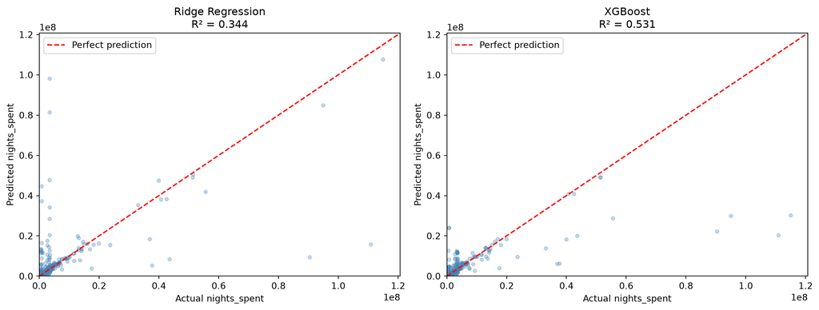

```python
fig, axes = plt.subplots(1, 2, figsize=(13, 5))

for ax, (name, pred) in zip(axes, [
    ('Ridge Regression', ridge_pred),
    ('XGBoost', xgb_reg_pred)
]):
    lim = [0, max(y_test_reg.max(), pred.max()) * 1.05]
    ax.scatter(y_test_reg, pred, alpha=0.3, s=15, color='steelblue')
    ax.plot(lim, lim, 'r--', linewidth=1.5, label='Perfect prediction')
    ax.set_xlim(lim); ax.set_ylim(lim)
    ax.set_xlabel('Actual nights_spent')
    ax.set_ylabel('Predicted nights_spent')
    r2 = r2_score(y_test_reg, pred)
    ax.set_title(f'{name}\nR² = {r2:.3f}')
    ax.legend()

plt.tight_layout()
plt.show()
```

## 8 · Benchmark Leaderboard & Honest Evaluation

### 8.1 · Classification leaderboard

```python
import pandas as pd
from sklearn.metrics import accuracy_score, f1_score, roc_auc_score

def clf_metrics(name, model, X, y_true, proba=None):
    pred = model.predict(X)
    acc  = accuracy_score(y_true, pred)
    f1   = f1_score(y_true, pred, average='macro', zero_division=0)
    auc  = (roc_auc_score(y_true, proba, multi_class='ovr')
            if proba is not None else float('nan'))
    return {'Model': name, 'Accuracy': acc, 'F1 (macro)': f1, 'ROC-AUC': auc}

rows_clf = [
    clf_metrics('Dummy (most frequent)',  dummy_clf, X_test, y_test_clf),
    clf_metrics('Logistic Regression',    lr_clf,    X_test, y_test_clf,
                lr_clf.predict_proba(X_test)),
    clf_metrics('Decision Tree',          dt_clf,    X_test, y_test_clf),
    clf_metrics('XGBoost (tuned)',        xgb_clf,   X_test, y_test_clf,
                xgb_clf.predict_proba(X_test)),
]

leaderboard_clf = pd.DataFrame(rows_clf).set_index('Model')
leaderboard_clf = leaderboard_clf.round(3)

# Highlight the best non-dummy row
print("=== Classification Leaderboard (TEST SET) ===")
print(leaderboard_clf.to_string())
print(f"\nBest model : XGBoost")
print(f"Beats dummy by: {leaderboard_clf.loc['XGBoost (tuned)','Accuracy'] - leaderboard_clf.loc['Dummy (most frequent)','Accuracy']:.3f} accuracy points")
```

[output not shown]

```python
# Styled table
leaderboard_clf.style \
    .highlight_max(color='#c6efce', subset=['Accuracy','F1 (macro)','ROC-AUC']) \
    .highlight_min(color='#ffc7ce', subset=['Accuracy','F1 (macro)']) \
    .format('{:.3f}', na_rep='—') \
    .set_caption('Table 1 — Classification leaderboard (test set)')
```

Table 1: Table 1 — Classification leaderboard (test set)

| Model | Accuracy | F1 (macro) | ROC-AUC |
| --- | --- | --- | --- |
| Dummy (most frequent) | 0.197 | 0.110 | — |
| Logistic Regression | 0.633 | 0.538 | 0.787 |
| Decision Tree | 0.718 | 0.708 | — |
| XGBoost (tuned) | 0.633 | 0.623 | 0.828 |

### 8.2 · Regression leaderboard

```python
from sklearn.metrics import r2_score, mean_absolute_error, mean_squared_error

def reg_metrics(name, model, X, y_true):
    pred = model.predict(X)
    return {
        'Model': name,
        'R²':    r2_score(y_true, pred),
        'MAE':   mean_absolute_error(y_true, pred),
        'RMSE':  mean_squared_error(y_true, pred) ** 0.5,
    }

rows_reg = [
    reg_metrics('Dummy (mean)',        dummy_reg, X_test, y_test_reg),
    reg_metrics('Ridge Regression',    ridge,     X_test, y_test_reg),
    reg_metrics('Decision Tree',       dt_reg,    X_test, y_test_reg),
    reg_metrics('XGBoost (tuned)',     xgb_reg,   X_test, y_test_reg),
]

leaderboard_reg = pd.DataFrame(rows_reg).set_index('Model')
leaderboard_reg[['MAE','RMSE']] = leaderboard_reg[['MAE','RMSE']].round(0)
leaderboard_reg['R²'] = leaderboard_reg['R²'].round(3)

print("=== Regression Leaderboard (TEST SET) ===")
print(leaderboard_reg.to_string())
```

```
=== Regression Leaderboard (TEST SET) ===
                     R²        MAE       RMSE
Model
Dummy (mean)     -0.002  1830959.0  6849780.0
Ridge Regression  0.344   878478.0  5541715.0
Decision Tree     0.428   752321.0  5175883.0
XGBoost (tuned)   0.531   667110.0  4686570.0
```

```python
leaderboard_reg.style \
    .highlight_max(color='#c6efce', subset=['R²']) \
    .highlight_min(color='#c6efce', subset=['MAE','RMSE']) \
    .highlight_min(color='#ffc7ce', subset=['R²']) \
    .format({'R²': '{:.3f}', 'MAE': '{:,.0f}', 'RMSE': '{:,.0f}'}) \
    .set_caption('Table 2 — Regression leaderboard (test set)')
```

Table 2: Table 2 — Regression leaderboard (test set)

| Model | R² | MAE | RMSE |
| --- | --- | --- | --- |
| Dummy (mean) | -0.002 | 1,830,959 | 6,849,780 |
| Ridge Regression | 0.344 | 878,478 | 5,541,715 |
| Decision Tree | 0.428 | 752,321 | 5,175,883 |
| XGBoost (tuned) | 0.531 | 667,110 | 4,686,570 |

> **Honest assessment:** XGBoost (R² = 0.53) explains about half the variance in nights_spent, which is meaningful but not excellent. The large RMSE reflects the enormous scale differences between countries — France’s peak month has 100× more nights than Luxembourg’s. A model predicting a single number for both will always have large absolute errors. This is a known limitation of the approach, not a modelling error.

### 8.3 · Train vs test gap — overfitting summary

```python
gap_data = {
    'Model': ['Decision Tree (clf)', 'XGBoost (clf)',
              'Decision Tree (reg)', 'XGBoost (reg)'],
    'Train score': [
        accuracy_score(y_train_clf, dt_clf.predict(X_train)),
        accuracy_score(y_train_clf, xgb_clf.predict(X_train)),
        r2_score(y_train_reg, dt_reg.predict(X_train)),
        r2_score(y_train_reg, xgb_reg.predict(X_train)),
    ],
    'Test score': [
        accuracy_score(y_test_clf, dt_clf.predict(X_test)),
        accuracy_score(y_test_clf, xgb_clf.predict(X_test)),
        r2_score(y_test_reg, dt_reg.predict(X_test)),
        r2_score(y_test_reg, xgb_reg.predict(X_test)),
    ],
}
gap_df = pd.DataFrame(gap_data).set_index('Model')
gap_df['Gap'] = (gap_df['Train score'] - gap_df['Test score']).round(3)
gap_df[['Train score','Test score']] = gap_df[['Train score','Test score']].round(3)
print(gap_df.to_string())
```

```
                     Train score  Test score    Gap
Model
Decision Tree (clf)        1.000       0.718  0.282
XGBoost (clf)              0.768       0.633  0.135
Decision Tree (reg)        1.000       0.428  0.572
XGBoost (reg)              0.991       0.531  0.459
```

## 9 · Feature Importance & Business Interpretation

### 9.1 · Feature importance — XGBoost classifier

XGBoost records how much each feature contributed to reducing prediction error across all trees. We extract feature names after one-hot encoding to get a readable plot.

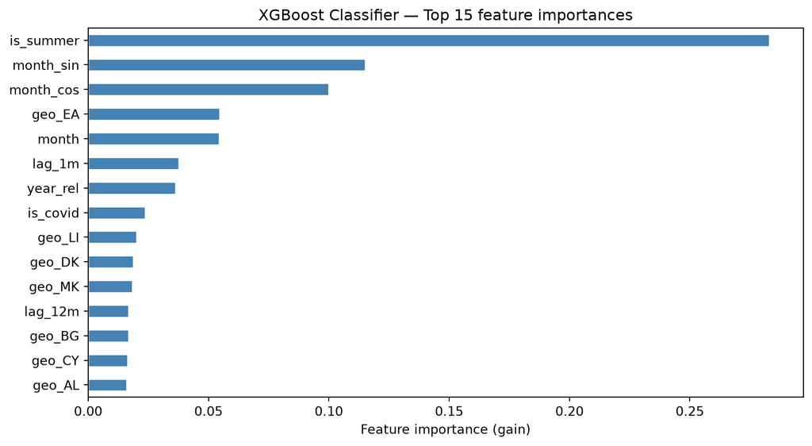

```
Top 10 features (classifier):
is_summer    0.2830
month_sin    0.1151
month_cos    0.1000
geo_EA       0.0547
month        0.0544
lag_1m       0.0377
year_rel     0.0363
is_covid     0.0237
geo_LI       0.0201
geo_DK       0.0187
```

```python
# Extract feature names from the fitted pipeline
ohe_features = (xgb_clf.named_steps['prep']
                .named_transformers_['cat']
                .get_feature_names_out(['geo'])
                .tolist())
all_feature_names = num_cols + ohe_features

importances_clf = pd.Series(
    xgb_clf.named_steps['clf'].feature_importances_,
    index=all_feature_names
).sort_values(ascending=False)

# Show top 15
top15_clf = importances_clf.head(15)

fig, ax = plt.subplots(figsize=(9, 5))
top15_clf[::-1].plot.barh(ax=ax, color='steelblue', edgecolor='white')
ax.set_title('XGBoost Classifier — Top 15 feature importances')
ax.set_xlabel('Feature importance (gain)')
plt.tight_layout()
plt.show()

print("Top 10 features (classifier):")
print(importances_clf.head(10).round(4).to_string())
```